# 2025 Gila Monster Occupancy Analysis

Sienna Solis-Stokes

2026-01-21

This document serves as a chronology of the analysis I’ve completed to date for the 2025 Gila monster occupancy project. I’ve excluded a decent amount of the code from this version of the document for a smoother read-through, if you’d like to see the entire code [visit this page](https://ssolisstokes.github.io/Thesis-Analysis/htmls/thesis-update-with-code.html).

# Summary Tables

This section contains summary tables relating to the survey design and effort (transect lengths and survey hours).

## Transect Distance by Site

```
## # A tibble: 6 × 5
##   site_id         n_transects avg_path_km total_path_km median_path_km
##   <chr>                 <int>       <dbl>         <dbl>          <dbl>
## 1 paradise_canyon          86        1.03          88.8           1.00
## 2 white_reef               86        1.01          86.7           1.00
## 3 fort_pearce              84        1.02          85.4           1.00
## 4 sun_river                83        1.01          84.0           1.00
## 5 cove_wash                81        1.01          81.7           1.00
## 6 turkey_farm              80        1.02          81.4           1.00
```

## Overall Transect Distance

```
## # A tibble: 1 × 4
##   n_transects avg_path_km total_path_km median_path_km
##         <int>       <dbl>         <dbl>          <dbl>
## 1         500        1.02           508           1.00
```

## Survey Effort

To quantify observer sampling effort, I calculated survey duration as the time difference between the start and end collection points for each transect, then multiplied by the number of observers present to estimate total person-hours. Tables show both field time effort (duration of a survey) and labor effort (total person-hours). Effort is summarized by site to evaluate even sampling hours across the study area.

## Effort by Site

```
## # A tibble: 6 × 5
##   site_id total_person_hours total_effort_hours avg_observers_per_su…¹ n_surveys
##   <chr>                <dbl>              <dbl>                  <dbl>     <int>
## 1 cove_w…                126                126                   1           81
## 2 fort_p…                130                118                   1.11        84
## 3 paradi…                144                138                   1.05        86
## 4 sun_ri…                135                134                   1.01        83
## 5 turkey…                131                121                   1.09        80
## 6 white_…                124                120                   1.03        86
## # ℹ abbreviated name: ¹avg_observers_per_survey
```

## Overall Effort

```
## # A tibble: 1 × 2
##   total_person_hours total_effort_hours
##                <dbl>              <dbl>
## 1                790                756
```

# Raw Data Plots

This section contains density and distribution plots of raw data. Before fitting occupancy models, I evaluated covariate distributions to check for outliers and visualize the data. Density plots were mainly to explore how environmental conditions differed between detection and non-detection points. These plots were exploratory and were not used directly for model selection.

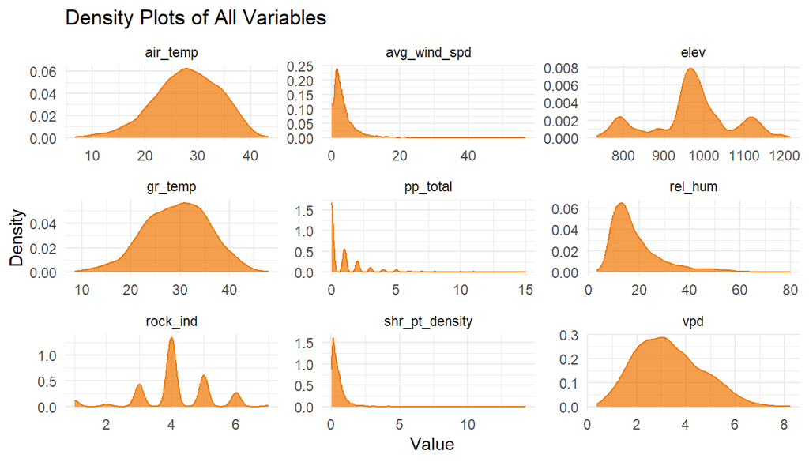

## Detection vs Non-Detection Distributions

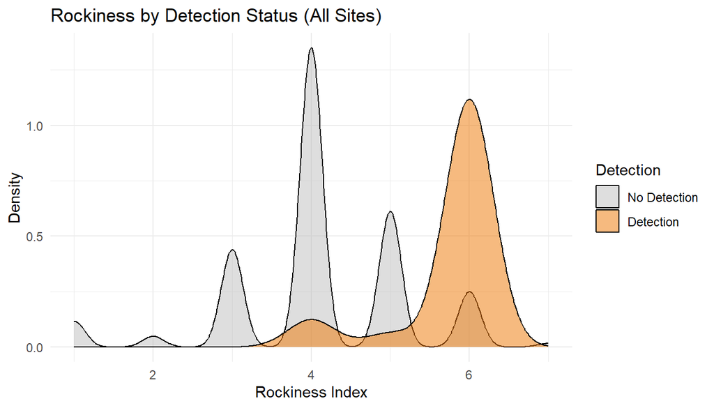

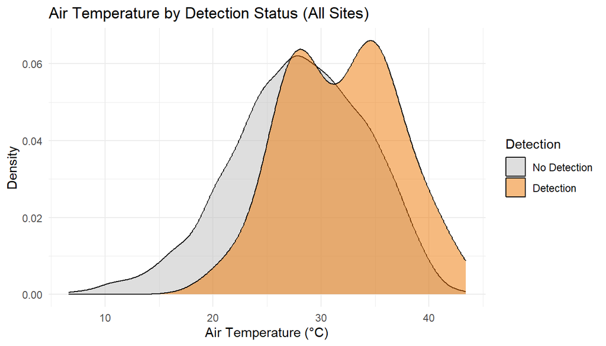

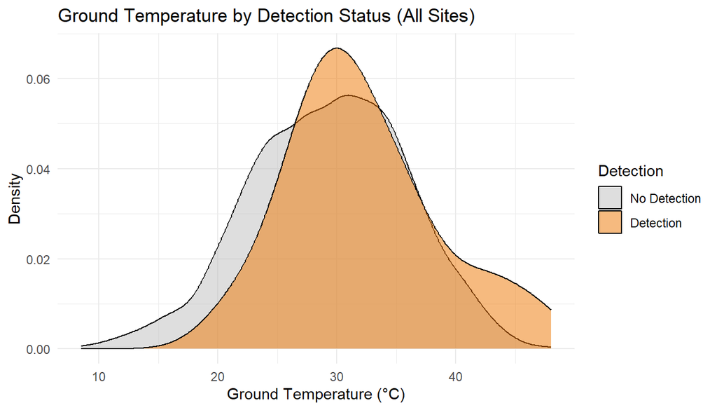

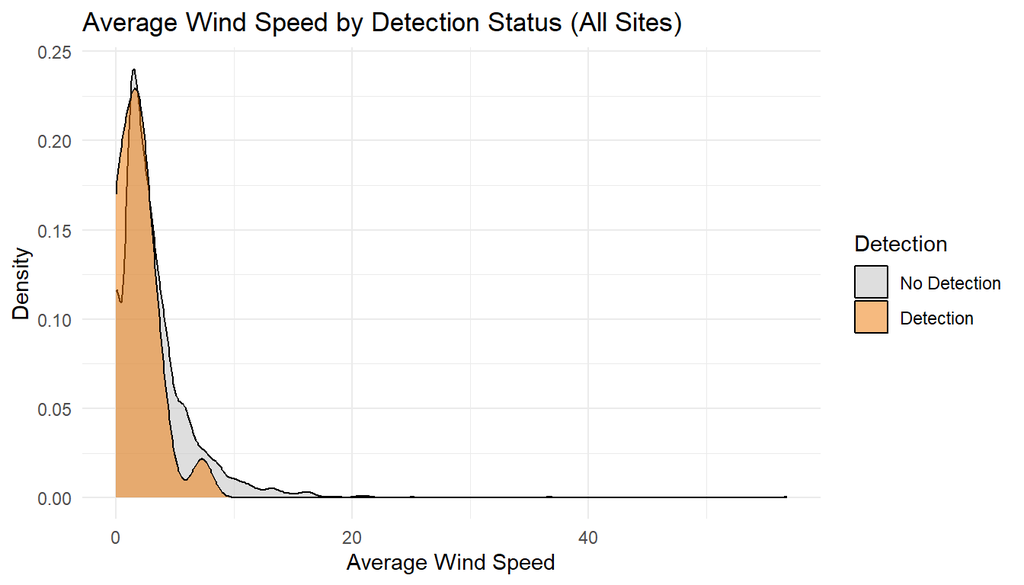

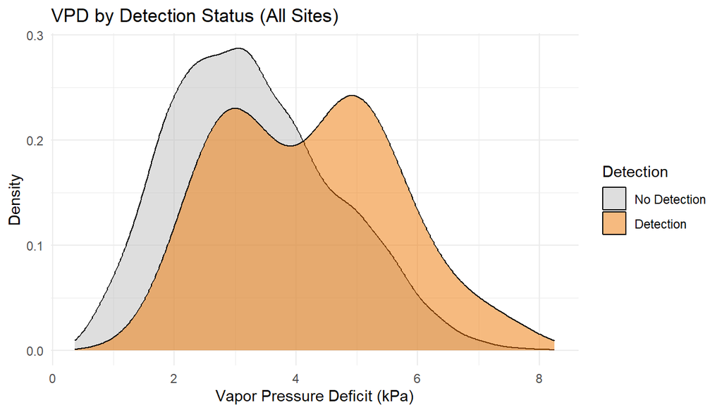

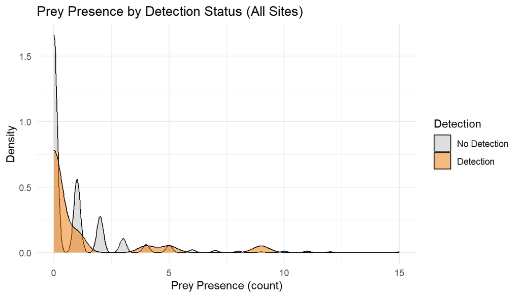

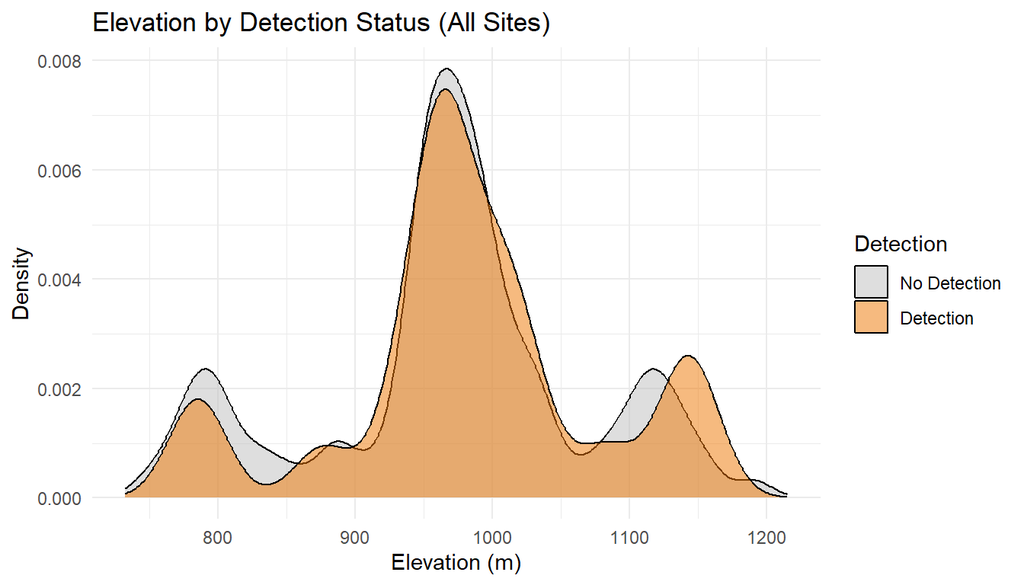

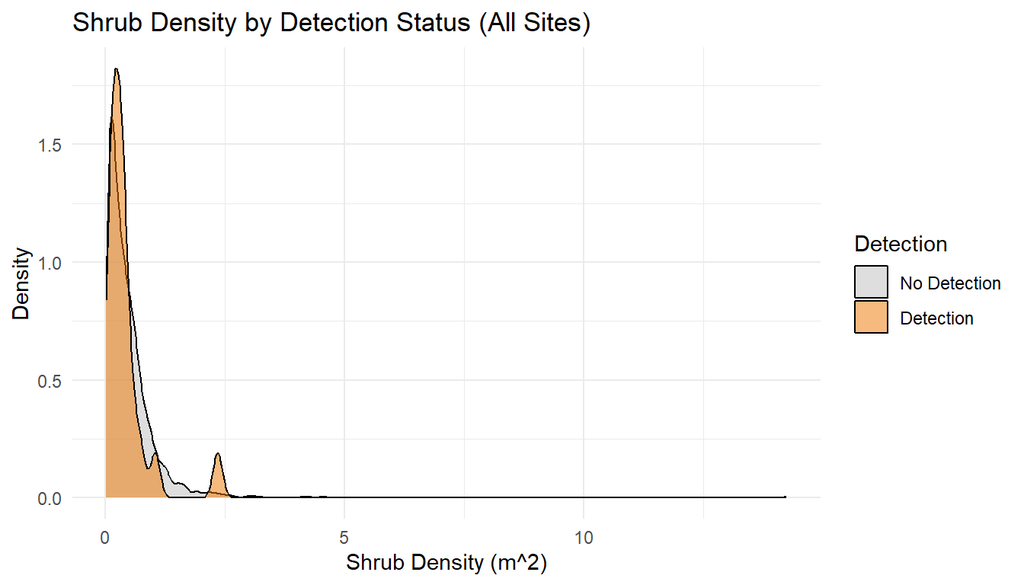

# Global Occupancy Model

This section contains the global model using spOccupancy::pgOcc. I utilized spOccupancy to fit a single-species Bayesian occupancy model that separates occupancy from detection probability through repeated transect surveys within sites. Models are fit using MCMC and Polya-Gamma data augmentation.

I cleaned the data prior to running models to exclude off-transect detections and ensure covariates were correctly aligned with the transect replicates. Site-level covariates were used to model occupancy (elevation, shrub density, prey presence, rockiness index), while transect-level covariates were used to model detection (air temperature, ground temperature, vapor pressure deficit, average wind speed, rockiness index). Prior to model fitting, all covariates were z-score standardized.

To fit the PGOcc framework, I constructed a site-level occupancy covariate dataframe with one row per site and a detection covariate list containing matrices with dimensions sites × replicates (transects). Detection covariates were summarized at the transect level, reshaped into replicate matrices, and aligned to the detection history matrix.

## MCMC, initial values, priors

```r
gm.inits <- list(
  alpha = 0,
  beta  = 0,
  z = apply(y, 1, max, na.rm = TRUE))

gm.priors <- list(
  alpha.normal = list(mean = 0, var = 2.72),
  beta.normal  = list(mean = 0, var = 2.72))

n.samples <- 10000
n.burn    <- 5000
n.thin    <- 5
n.chains  <- 3
```

## Global Model Fit (pgOcc)

```
##
## Call:
## PGOcc(occ.formula = global.occ.formula, det.formula = global.det.formula,
##     data = list(y = y, occ.covs = occ.cov_df, det.covs = det.cov_list),
##     inits = gm.inits, priors = gm.priors, n.samples = n.samples,
##     n.omp.threads = 1, verbose = FALSE, n.report = 2000, n.burn = n.burn,
##     n.thin = n.thin, n.chains = n.chains)
##
## Samples per Chain: 10000
## Burn-in: 5000
## Thinning Rate: 5
## Number of Chains: 3
## Total Posterior Samples: 3000
## Run Time (min): 0.1325
##
## Occurrence (logit scale):
##                Mean     SD    2.5%     50%  97.5%   Rhat  ESS
## (Intercept)  1.8310 1.0394 -0.0626  1.7867 3.9515 1.0024 3000
## rockiness   -0.9679 1.1454 -3.2228 -0.9537 1.1648 0.9999 3000
## shrubs       1.2997 1.1632 -0.8736  1.2633 3.6452 1.0022 3000
## elev        -0.2753 1.2399 -2.5656 -0.3389 2.2916 1.0083 2694
## prey        -0.9355 1.1145 -3.1523 -0.9309 1.2155 1.0036 3181
##
## Detection (logit scale):
##                Mean     SD    2.5%     50%   97.5%   Rhat  ESS
## (Intercept) -3.4875 0.4425 -4.3993 -3.4662 -2.6561 1.0001 1194
## rock         0.4793 0.2437  0.0015  0.4733  0.9803 1.0074 1936
## I(t_air^2)  -0.2233 0.5103 -1.2837 -0.2126  0.6992 1.0470  698
## t_air       -0.2134 0.9848 -2.1684 -0.2062  1.7233 1.0010 2131
## vpd          2.9051 0.9866  1.0305  2.8901  4.8603 1.0009 1595
## wind        -1.1561 0.4854 -2.1540 -1.1380 -0.2749 1.0212  930
## I(t_gr^2)   -0.7638 0.4773 -1.7592 -0.7495  0.1356 1.0034 1278
## t_gr        -1.7345 0.6488 -3.0070 -1.7353 -0.4272 1.0090 1910
```

In the global model, all occupancy covariates had 95% credible intervals overlapping zero, indicating significant uncertainty in the magnitude and direction of individual habitat effects on occupancy. This is not unexpected given the small number of sites and low detection frequency (17 detections across 500 transects), and it reinforces the need for model selection and model averaging to better assess habitat–occupancy relationships.

Overall, the global model suggests detectability is driven more by short-term/survey level environmental conditions than occupancy is by site-level habitat covariates (in this dataset).

## Diagnostics & Posterior Predictive Checks

This section contains trace plots to evaluate adequate MCMC mixing and convergence, and posterior predictive checks using the Freeman-Tukey statistic and chi-squared test summarized at both the site and transect level.

### MCMC Trace Plots

In these plots we’re looking for what is called a “hairy caterpillar”. In the lines we hope to see high overlap, and no flat sections or clear trend lines to show that chains are well-mixed. These plots indicate model convergence and adequate model fit.

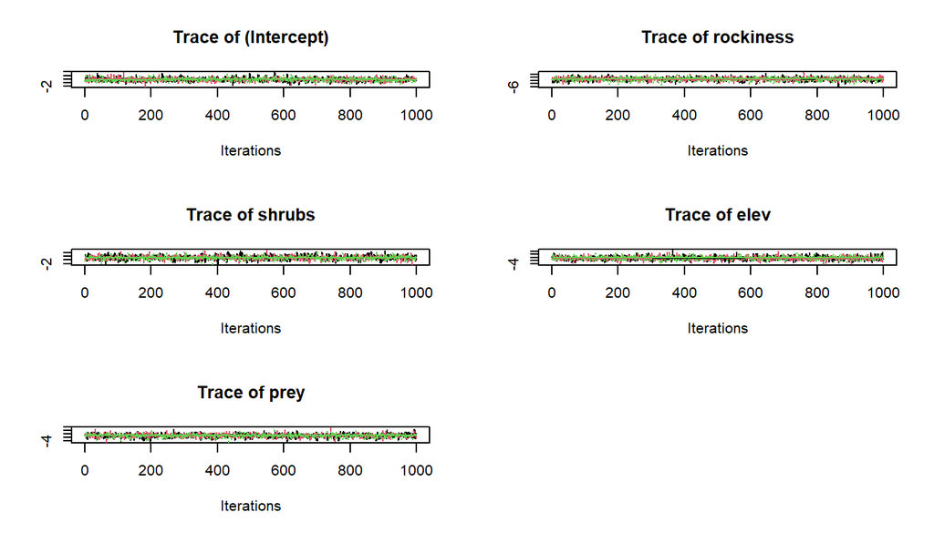

```r
plot(global_model, "beta", density = FALSE) # occupancy parameters
```

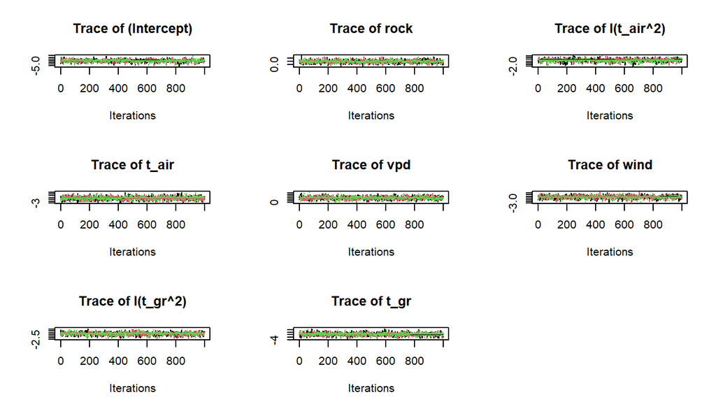

```r
plot(global_model, "alpha", density = FALSE) # detection parameters
```

### Posterior Predictive Checks

spOccupancy contains the ppcOcc() function, which groups the data by row (site) or by column (replicate) and calculates a fit statistic. ppcOcc() returns posterior samples of the fit statistic for the observed dataset and for replicated datasets generated under the model. The function supports the Freeman–Tukey and chi-squared statistics. A Bayesian p-value near 0.5 indicates adequate fit, while values < 0.1 or > 0.9 suggest lack of fit.

### Freeman-Tukey Test

```
##
## Call:
## ppcOcc(object = global_model, fit.stat = "freeman-tukey", group = 1)
##
## Samples per Chain: 10000
## Burn-in: 5000
## Thinning Rate: 5
## Number of Chains: 3
## Total Posterior Samples: 3000
##
## Bayesian p-value:  0.367
## Fit statistic:  freeman-tukey
```

```
##
## Call:
## ppcOcc(object = global_model, fit.stat = "freeman-tukey", group = 2)
##
## Samples per Chain: 10000
## Burn-in: 5000
## Thinning Rate: 5
## Number of Chains: 3
## Total Posterior Samples: 3000
##
## Bayesian p-value:  0.6103
## Fit statistic:  freeman-tukey
```

### Chi-Squared Test

```
##
## Call:
## ppcOcc(object = global_model, fit.stat = "chi-squared", group = 1)
##
## Samples per Chain: 10000
## Burn-in: 5000
## Thinning Rate: 5
## Number of Chains: 3
## Total Posterior Samples: 3000
##
## Bayesian p-value:  0.2633
## Fit statistic:  chi-squared
```

```
##
## Call:
## ppcOcc(object = global_model, fit.stat = "chi-squared", group = 2)
##
## Samples per Chain: 10000
## Burn-in: 5000
## Thinning Rate: 5
## Number of Chains: 3
## Total Posterior Samples: 3000
##
## Bayesian p-value:  0.647
## Fit statistic:  chi-squared
```

Bayesian p-values for the site and replicate data using the Chi-squared test fall within acceptable ranges indicating no lack of fit.

# Collinearity Assessment

To evaluate multicollinearity I examined variance inflation factors (VIFs) and correlation matrices for occupancy and detection covariates separately.

## Occupancy Variables

```
##           rockiness shrubs elev  prey
## rockiness      1.00   0.23 0.15 -0.04
## shrubs         0.23   1.00 0.66  0.16
## elev           0.15   0.66 1.00  0.48
## prey          -0.04   0.16 0.48  1.00
```

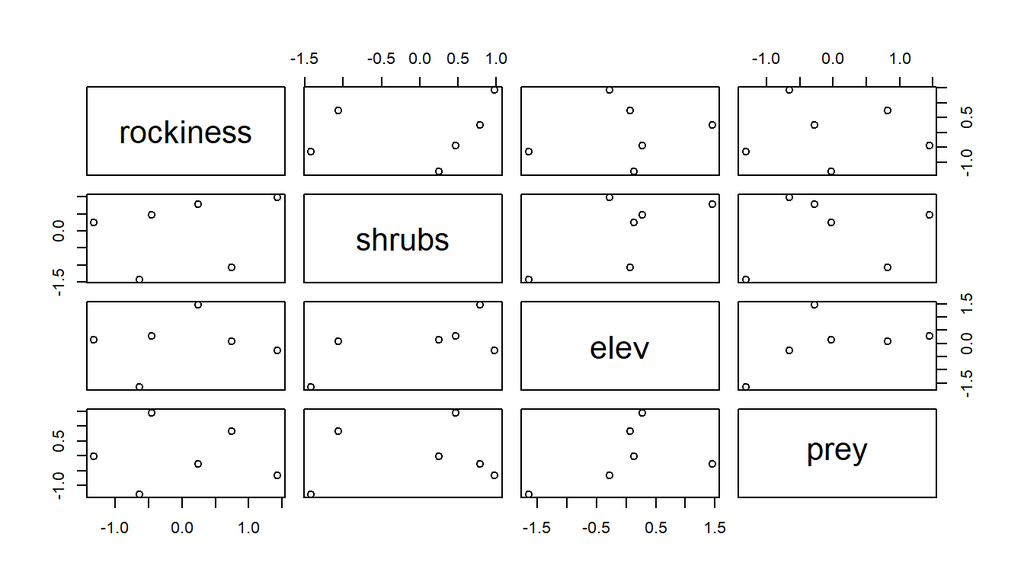

```
## rockiness    shrubs      elev      prey
##      1.07      1.91      2.36      1.38
```

Correlation coefficients among occupancy covariates are generally low, with the strongest correlation between shrub density and elevation. Prey presence shows a moderate correlation with elevation and any correlations involving rockiness were low/weak. VIFs are all < 3, which is well under the commonly used threshold for problematic multicollinearity. Overall, although a few covariates show moderate correlation, multicollinearity is unlikely to meaningfully impact model stability, and all occupancy covariates were retained for model selection.

## Detection Variables

```
##        rock t_air  t_gr   vpd  wind
## rock   1.00 -0.05 -0.01 -0.06 -0.01
## t_air -0.05  1.00  0.91  0.95  0.03
## t_gr  -0.01  0.91  1.00  0.90  0.15
## vpd   -0.06  0.95  0.90  1.00  0.11
## wind  -0.01  0.03  0.15  0.11  1.00
```

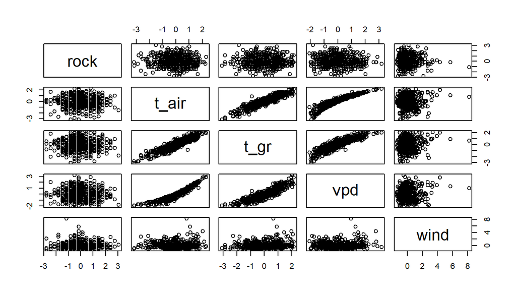

```
##  rock t_air  t_gr   vpd  wind
##  1.01 13.91  6.98 10.74  1.13
```

Correlation coefficients among detection covariates show a strong correlation among any weather-related variables. Air temperature, ground temperature, and vapor pressure deficit were all highly correlated. In contrast, rockiness and wind showed weak correlation with other detection covariates. VIFs show the same pattern with values very high for air temperature and vapor pressure deficit, and moderately high for ground temperature all exceeding the commonly used threshold. To avoid model instability, detection models did not include multiple highly collinear predictors simultaneously.

# Occupancy Covariate Selection

To start the model-selection process, I constructed occupancy covariate models using candidate occupancy formulas and the global detection formula. I created candidate occupancy covariate formulas representing biological hypotheses for how occupancy varies with habitat structure. Models were compared using WAIC, and model weights (derived from WAIC differences) were used to calculate variable importance and quantify model support. Additionally, I calculated model-averaged coefficients to provide a single weighted estimate of covariate effects across models.

Candidate Model list:  
- om1: ~1  
- om2: ~ rockiness + shrubs + elev  
- om3: ~ rockiness + shrubs + prey  
- om4: ~ rockiness + shrubs  
- om5: ~ rockiness + prey  
- om6: ~ shrubs + prey  
- om7: ~ rockiness  
- om8: ~ shrubs

## WAIC Table

```
##   model      elpd       pD     WAIC     delta     weight
## 1   om3 -54.54544 8.061174 125.2132 0.0000000 0.20060948
## 2   om1 -55.75777 7.027221 125.5700 0.3567504 0.16783560
## 3   om6 -54.88858 8.095074 125.9673 0.7540923 0.13759492
## 4   om4 -54.89162 8.140095 126.0634 0.8502080 0.13113878
## 5   om2 -54.66640 8.415962 126.1647 0.9515017 0.12466240
## 6   om8 -55.23380 8.194525 126.8566 1.6434237 0.08820365
## 7   om7 -55.63388 7.884290 127.0363 1.8231140 0.08062454
## 8   om5 -55.20243 8.466654 127.3382 2.1249467 0.06933063
```

Model selection shows most candidate models with delta <2, indicating an overall similar predictive power among models. Model weights are similarly distributed across candidate models, with model om3 exhibiting a slightly higher weight.

## Variable Importance

```
##    variable sum_weight
## 1 rockiness  0.6063658
## 2     shrub  0.6822092
## 3      elev  0.1246624
## 4      prey  0.4075350
```

The most consistently supported predictors of occupancy after calculating summed model weights are shrub density and rockiness. Prey presence shows moderate support while elevation has the weakest support. These results suggest that vegetation structure and substrate characteristics are more important factors when predicting Gila monster site occupancy than elevation or observed adult prey presence in this dataset.

## Model-Averaged Coefficients

```
##          term avg_coefficients
## 1 (Intercept)       1.59660636
## 2   rockiness      -0.51504310
## 3      shrubs       0.77591267
## 4        elev      -0.07459934
## 5        prey      -0.37597438
```

Model-averaged coefficients suggest that occupancy increases with shrub density and decreases with rockiness index, while elevation and prey presence show weaker effects. Because coefficients were model-averaged, these values reflect both effect magnitude and frequency with which variables appeared in candidate models. This reinforces the importance of habitat structure in predicting Gila monster site occupancy.

## Final Occupancy Formula

Based on WAIC model selection and variable importance results, the final occupancy formula selected is: (~ rockiness + shrubs) for the most parsimonious and biologically meaningful model. Model selection indicates candidate models containing rockiness and shrub density receive the strongest support and variable-importance results show both contribute strongly to explaining Gila monster site occupancy.

# Detection Covariate Selection

After selecting the best-fit occupancy covariate formula, I followed the same workflow as the previous section but for the detection formula. Within this set of candidate models, one model was tested with occupancy set to 1. The goal of this model selection process was to identify the most parsimonious detection formula which improves model fit while avoiding unnecessary model complexity.

Candidate Model list:  
- dm1: ~ 1  
- dm2: ~ rock  
- dm3: ~ t_gr + I(t_gr^2)  
- dm4: ~ rock + wind  
- dm5: ~ rock + t_gr + I(t_gr^2)  
- dm6: ~ wind + t_gr + I(t_gr^2)  
- dm7: ~ rock + wind + t_gr + I(t_gr^2)

## WAIC Table

```
##   model      elpd       pD     WAIC      delta      weight
## 1   dm4 -67.58655 4.999120 145.1713  0.0000000 0.458724106
## 2   dm6 -67.83656 5.189170 146.0515  0.8801238 0.295416744
## 3   dm7 -66.39147 6.967518 146.7180  1.5466528 0.211689914
## 4   dm1 -72.62169 3.265744 151.7749  6.6035264 0.016889392
## 5   dm2 -71.22329 5.499756 153.4461  8.2747629 0.007323347
## 6   dm3 -71.48349 5.277422 153.5218  8.3504985 0.007051213
## 7   dm5 -69.99166 7.655925 155.2952 10.1238363 0.002905283
```

Detection model selection shows top models with delta <2 containing some combination of wind, rockiness, and ground temperature effects. Models lacking these covariates or including only a single predictor are weaker and contribute minimal model weight.

## Variable Importance

```
##   variable sum_weight
## 1     rock  0.6806427
## 2     t_gr  0.5170632
## 3     wind  0.9658308
```

Summed model weights indicate wind is the most consistently supported predictor of detection across candidate models. Rockiness shows moderate support, followed by ground temperature with slightly lower support. This suggests that detection probability decreased under windy conditions, most likely due to reduced track persistence and visibility in loose sand. Rockiness also shows significant support, consistent with tracks being easier to detect on sandier substrates that retain Gila monster sign than rockier surfaces.

## Model-Averaged Coefficients

```
##                    term avg_coefficients
## (Intercept) (Intercept)       -3.3330921
## rock               rock        0.2365158
## t_gr               t_gr        0.2369394
## I(t_gr^2)     I(t_gr^2)       -0.2472961
## wind               wind       -1.0439067
```

Model-averaged coefficients show that detection probability is primarily influenced by wind (negative effect), rockiness (positive effect), and nonlinear ground temperature effects. Overall this reinforces that environmental conditions and substrate characteristics strongly impact detection probability, and emphasizes the importance of modeling detectability when surveying cryptic species.

## Initial Detection Formula

Based on WAIC model selection and variable importance results, the final detection model formula contains rockiness and wind as detection covariates (~ rock + wind). Results show that substrate type and wind conditions explain the majority of variation in detection probability, and the addition of ground temperature did not provide significant improvement to the model fit.

# Bootstrap Analysis

As a complementary analysis to analyze detection at a collection point level versus the transect level I used stratified bootstrap resampling to estimate differences in mean covariate values between detection and non-detection observations. Bootstrap confidence intervals and two-sided p-values in this section summarize how consistently each covariate differs between the two groups under resampling.

## Bootstrap Results Summary

```
## # A tibble: 5 × 5
##   variable        lcl    med    ucl p_value
##   <chr>         <dbl>  <dbl>  <dbl>   <dbl>
## 1 rock_ind      1.24   1.62   1.90    0
## 2 air_temp      1.53   4.01   6.62    0.002
## 3 gr_temp      -0.488  2.10   5.06    0.112
## 4 avg_wind_spd -2.23  -1.35  -0.310   0.02
## 5 vpd           0.350  0.981  1.69    0.004
```

The bootstrap analysis indicates that detections occurred under a higher rockiness index value (sandier substrates), higher air temperature, lower wind speed, and higher vapor pressure deficit compared to non-detections. Ground temperature differences were small, with confidence intervals overlapping zero, indicating weak and inconsistent differences between detection and non-detection observations. Overall, the bootstrap results support rockiness, air temperature, wind speed, and vapor pressure deficit as covariates that differ consistently between detection and non-detection observations, while ground temperature shows weak evidence.

In the following sections histograms of results and box plots of raw data help to visualize these results.

## Bootstrap Distributions

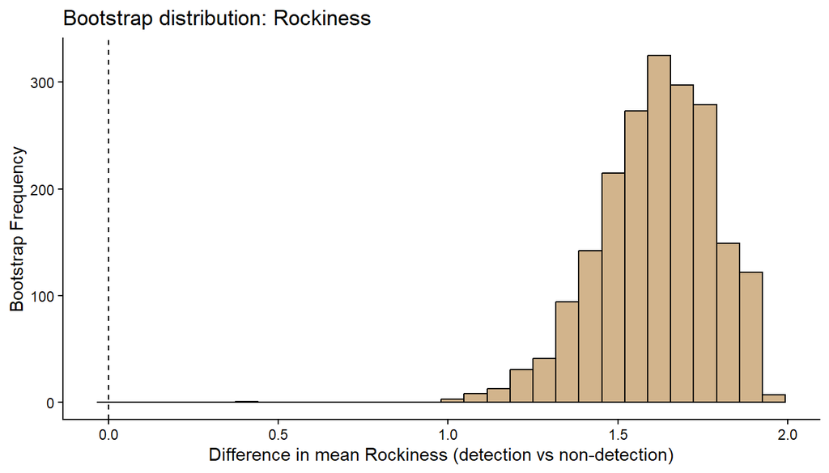

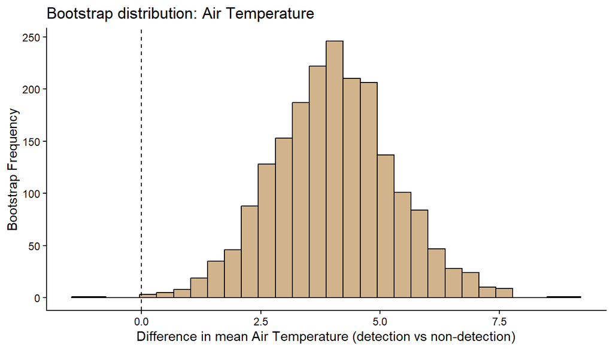

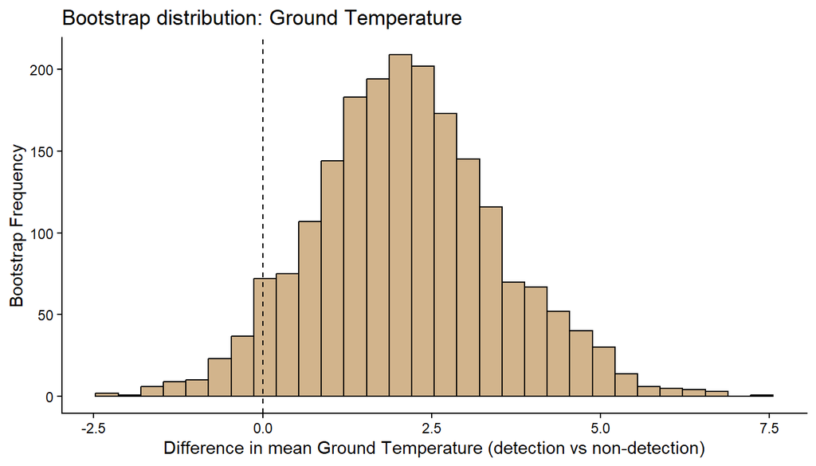

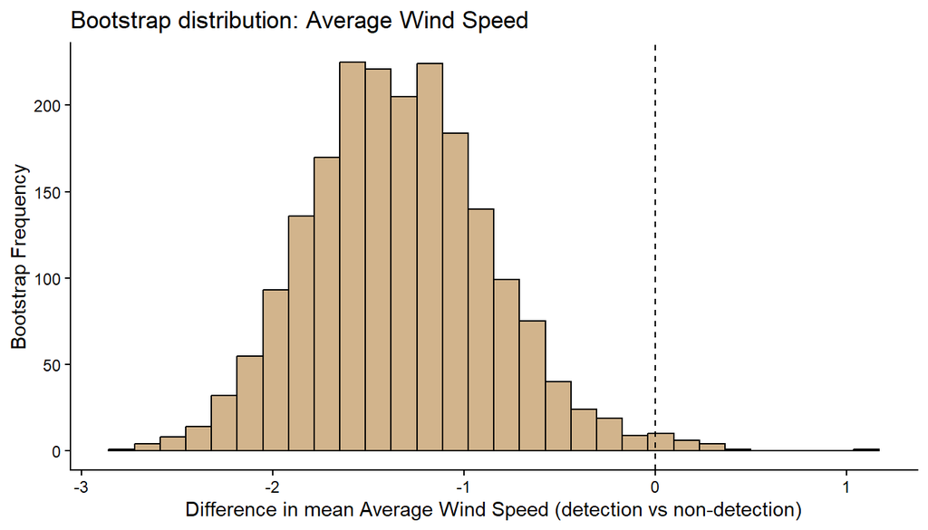

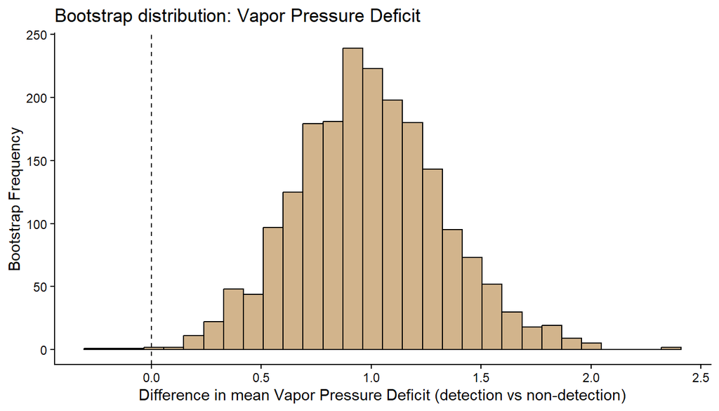

## Bootstrap Boxplots

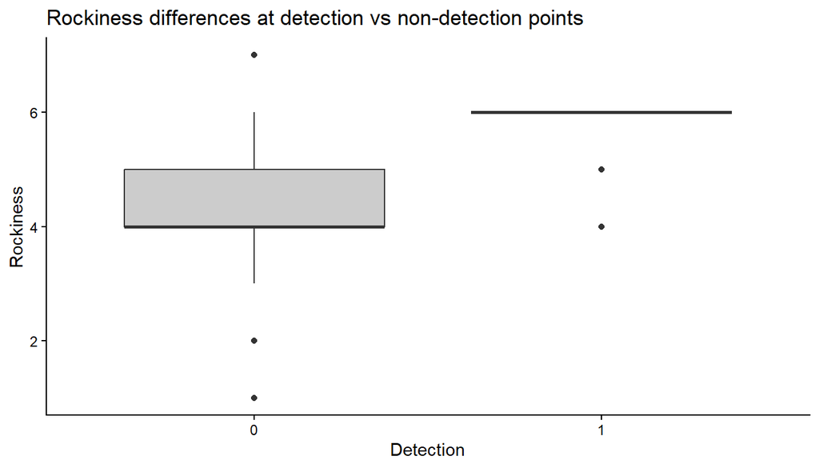

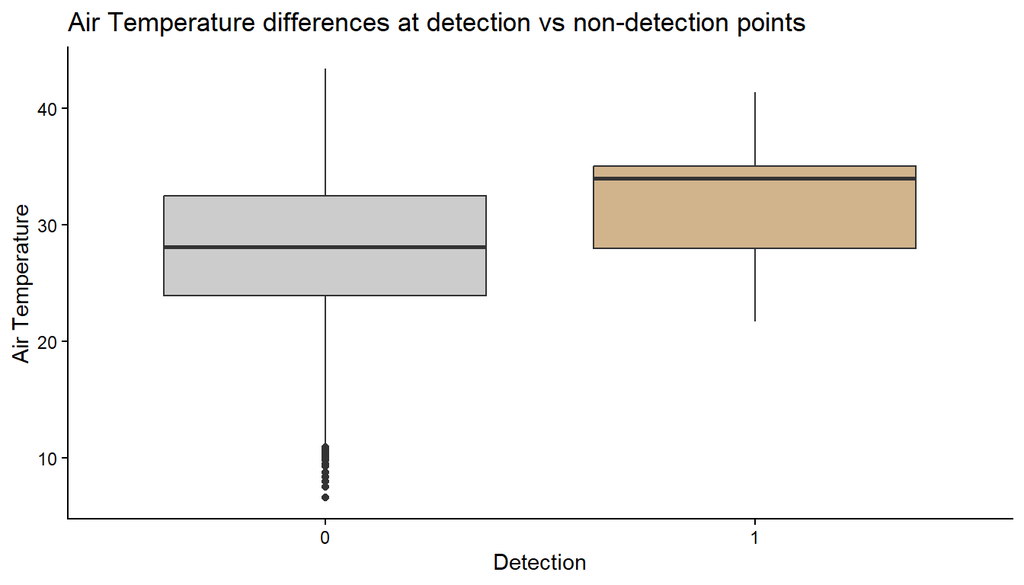

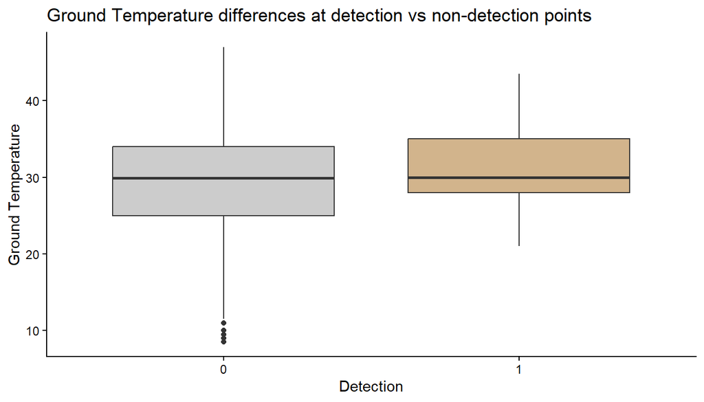

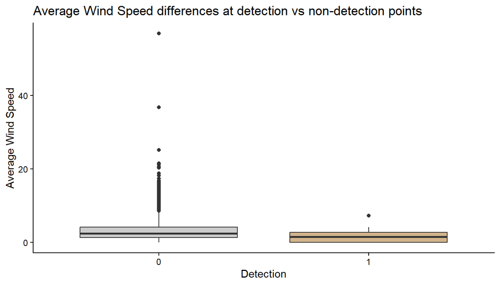

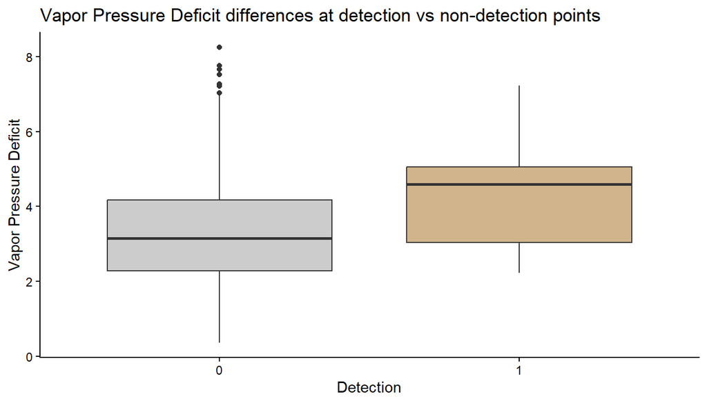

# Re-run Detection Selection

After completing the bootstrap analysis I expanded the detection candidate set to include air temperature (with its quadratic term) alone and in combination with rock and wind. The goal of this process was to test whether air temperature explains any additional detection variation. This section contains updated model selection results which were used to select the final detection formula for best-fit model comparison.

Added Candidate Models:  
- dm8: ~ t_air + I(t_air^2)  
- dm9: ~ wind + t_air + I(t_air^2)  
- dm10: ~ rock + t_air + I(t_air^2)  
- dm11: ~ rock + wind + t_air + I(t_air^2)

## WAIC Table

```
##    model      elpd       pD     WAIC     delta       weight
## 1    dm9 -65.94941 3.858335 139.6155  0.000000 0.5680981261
## 2   dm11 -64.07135 6.254263 140.6512  1.035740 0.3384662165
## 3    dm4 -67.58655 4.999120 145.1713  5.555839 0.0353173624
## 4    dm6 -67.83656 5.189170 146.0515  6.435963 0.0227442598
## 5    dm7 -66.39147 6.967518 146.7180  7.102492 0.0162980958
## 6    dm8 -69.65906 4.050929 147.4200  7.804493 0.0114735858
## 7   dm10 -67.83169 6.714599 149.0926  9.477085 0.0049716497
## 8    dm1 -72.62169 3.265744 151.7749 12.159365 0.0013003214
## 9    dm2 -71.22329 5.499756 153.4461 13.830602 0.0005638276
## 10   dm3 -71.48349 5.277422 153.5218 13.906337 0.0005428759
## 11   dm5 -69.99166 7.655925 155.2952 15.679675 0.0002236790
```

## Variable Importance

```
##   variable sum_weight
## 1     rock 0.39584083
## 2     t_gr 0.03980891
## 3     wind 0.98092406
## 4    t_air 0.92300958
```

Updated variable importance results show wind and air temperature were included in nearly all top-supported models, suggesting consistent support for both as predictors of detectability. Rockiness maintained moderate support but was less consistently selected after adding air temperature than when air temperature was excluded. Ground temperature shows the weakest support.

## Model-averaged Coefficients

```
##             avg_coefficients
## (Intercept)      -3.55313388
## rock              0.14685732
## t_air             0.88465262
## I(t_air^2)       -0.26193088
## t_gr              0.01824207
## I(t_gr^2)        -0.01903943
## wind             -1.07005579
```

## Best-fit Detection Formulas

# Best-fit Model

In this section final occupancy and detection formulas are combined to fit a best-supported occupancy model. Model performance is evaluated relative to global and null occupancy models using WAIC and k-fold cross-validation, and model fit is assessed using Freeman–Tukey and chi-squared posterior predictive checks.

## Best-fit WAIC Table

```
##            model      elpd       pD     WAIC    delta       weight
## 1   global_model -54.50822 8.201733 125.4199  0.00000 0.9988803419
## 2 best.fit_model -64.19595 5.979337 140.3506 14.93068 0.0005719496
## 3     null_model -65.06143 5.157163 140.4372 15.01729 0.0005477085
```

Comparing WAIC among the global, best-fit, and null models shows the global model with the lowest WAIC. However, the global model includes multiple highly collinear detection covariates (air temperature, vapor pressure deficit, and ground temperature), increasing the risk of overparameterization and reducing interpretability of individual effects.

To prioritize parsimony and biological inference, I have chosen the reduced detection model including wind, rockiness, and air temperature (with a quadratic term). This model performs well relative to the null model and avoids multicollinearity among detection predictors.

## Best-fit K-fold Cross-validation

```
##     global     best     null
## 1 146.0035 142.6266 149.6774
```

K-fold cross-validation further supports selection of the reduced best-fit model. The best-fit model shows the lowest k-fold deviance, indicating better out-of-sample predictive performance relative to both the global model and the null model. These results show that although the global model results in higher WAIC support, the reduced model provides a more parsimonious/improved performance.

## Model Summary

After comparing WAIC, k-fold cross-validation deviance, and taking into account predictor variable collinearity, the final best fit model can now be used to estimate covariate effects and generate posterior predictions.

```
##
## Call:
## PGOcc(occ.formula = fit.occupancy.formula, det.formula = fit.detection.formula,
##     data = list(y = y, occ.covs = occ.cov_df, det.covs = det.cov_list),
##     inits = gm.inits, priors = gm.priors, n.samples = n.samples,
##     n.omp.threads = 1, verbose = FALSE, n.report = 2000, n.burn = n.burn,
##     n.thin = n.thin, n.chains = n.chains)
##
## Samples per Chain: 10000
## Burn-in: 5000
## Thinning Rate: 5
## Number of Chains: 3
## Total Posterior Samples: 3000
## Run Time (min): 0.1208
##
## Occurrence (logit scale):
##                Mean     SD    2.5%     50%  97.5%   Rhat  ESS
## (Intercept)  1.6481 1.0024 -0.1878  1.6088 3.7704 1.0016 3000
## rockiness   -0.8535 1.0856 -3.0428 -0.8423 1.3018 0.9997 3000
## shrubs       1.0648 1.0042 -0.9489  1.0519 3.0313 1.0010 3000
##
## Detection (logit scale):
##                Mean     SD    2.5%     50%   97.5%   Rhat  ESS
## (Intercept) -3.6202 0.4072 -4.4671 -3.6073 -2.8803 1.0070 1193
## rock         0.3824 0.2381 -0.0727  0.3817  0.8587 1.0010 2158
## wind        -1.1031 0.4489 -2.0253 -1.0849 -0.2892 1.0223  993
## t_air        0.9715 0.4122  0.2927  0.9166  1.9430 1.0519  322
## I(t_air^2)  -0.2715 0.3129 -1.0045 -0.2336  0.2375 1.0577  375
```

```
##      2.5%       50%     97.5%
## 0.4531879 0.8332425 0.9774765
```

```
##       2.5%        50%      97.5%
## 0.01135036 0.02640946 0.05313696
```

Additionally, from the model summary we can calculate predicted occupancy and detection probability across the study area under mean site conditions. The final model predicts probability of site occupancy at 83% and detection probability during a survey 2.7%. These results indicate that sites were likely occupied across the study area, but that individual surveys had a low probability of detecting the species even when present.

## Freeman-Tukey Test

```
##
## Call:
## ppcOcc(object = best.fit_model, fit.stat = "freeman-tukey", group = 2)
##
## Samples per Chain: 10000
## Burn-in: 5000
## Thinning Rate: 5
## Number of Chains: 3
## Total Posterior Samples: 3000
##
## Bayesian p-value:  0.5283
## Fit statistic:  freeman-tukey
```

```
##
## Call:
## ppcOcc(object = best.fit_model, fit.stat = "freeman-tukey", group = 1)
##
## Samples per Chain: 10000
## Burn-in: 5000
## Thinning Rate: 5
## Number of Chains: 3
## Total Posterior Samples: 3000
##
## Bayesian p-value:  0.3997
## Fit statistic:  freeman-tukey
```

Bayesian p-values for the site and replicate data using the Freeman-Tukey test fall within acceptable ranges indicating no lack of fit, the following plots aid in visualizing the replicate data set vs the actual dataset.

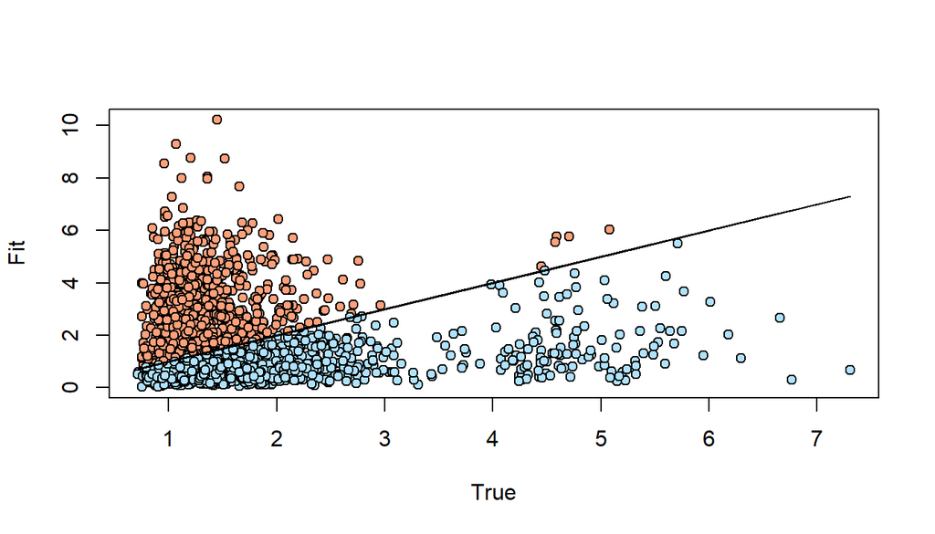

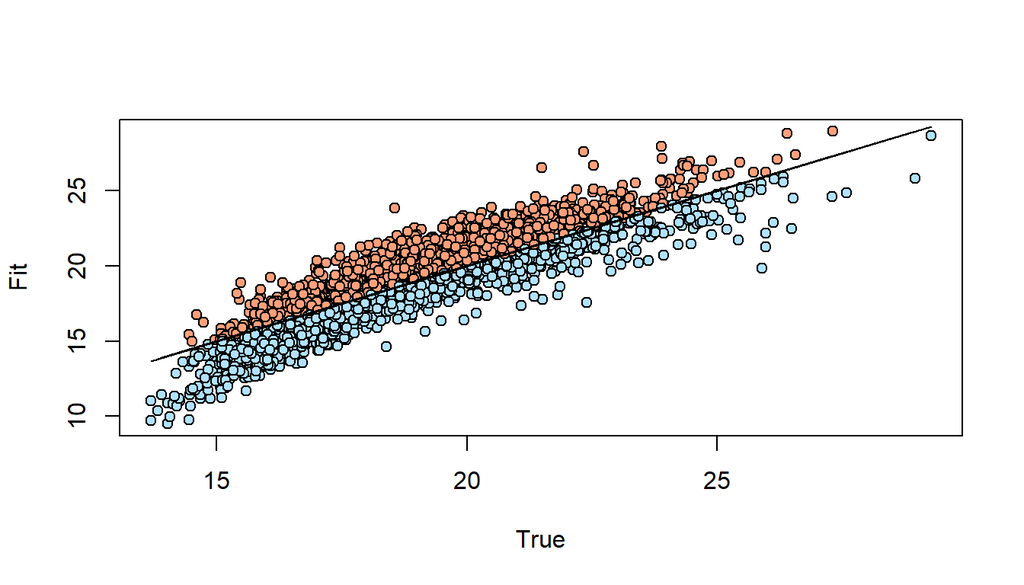

## Chi-Squared Test

```
##
## Call:
## ppcOcc(object = best.fit_model, fit.stat = "chi-squared", group = 1)
##
## Samples per Chain: 10000
## Burn-in: 5000
## Thinning Rate: 5
## Number of Chains: 3
## Total Posterior Samples: 3000
##
## Bayesian p-value:  0.3293
## Fit statistic:  chi-squared
```

```
##
## Call:
## ppcOcc(object = best.fit_model, fit.stat = "chi-squared", group = 2)
##
## Samples per Chain: 10000
## Burn-in: 5000
## Thinning Rate: 5
## Number of Chains: 3
## Total Posterior Samples: 3000
##
## Bayesian p-value:  0.578
## Fit statistic:  chi-squared
```

Bayesian p-values for the site and replicate data using the Chi-squared test fall within acceptable ranges indicating no lack of fit.

# Habitat Class Comparison

Sites were apriori selected based on a habitat quality index: low, medium, and high. Habitat quality was established based on site topography, native plant diversity and abundance, habitat patch size, fire history, proximity to urban development, and Gila monster sighting records from 1900 - 2024. To explore differences in occupancy among habitat classes, this section retains the final detection model and occupancy is reparameterized as a categorical habitat effect. Posterior predictions are then converted to occupancy probabilities and credible intervals for each habitat class. Additionally, posterior probabilities are compared to quantify the strength of evidence that occupancy differs among habitat classes.

## Habitat Model Summary

```
##
## Call:
## PGOcc(occ.formula = habitat.occ.formula, det.formula = fit.detection.formula,
##     data = list(y = y, occ.covs = occ.cov_df, det.covs = det.cov_list),
##     inits = gm.inits, priors = gm.priors, n.samples = n.samples,
##     n.omp.threads = 1, verbose = FALSE, n.report = 2000, n.burn = n.burn,
##     n.thin = n.thin, n.chains = n.chains)
##
## Samples per Chain: 10000
## Burn-in: 5000
## Thinning Rate: 5
## Number of Chains: 3
## Total Posterior Samples: 3000
## Run Time (min): 0.123
##
## Occurrence (logit scale):
##                 Mean     SD    2.5%    50%  97.5%   Rhat  ESS
## (Intercept)   1.0393 1.0363 -0.8778 0.9671 3.2626 1.0035 2808
## habitatmedium 1.0127 1.3430 -1.6528 0.9801 3.7156 1.0048 3533
## habitathigh   0.9834 1.3885 -1.6561 0.9115 3.8212 1.0060 2146
##
## Detection (logit scale):
##                Mean     SD    2.5%     50%   97.5%   Rhat  ESS
## (Intercept) -3.6072 0.4077 -4.4612 -3.5889 -2.8622 1.0073 1209
## rock         0.3738 0.2429 -0.1008  0.3759  0.8584 1.0002 1993
## wind        -1.0750 0.4441 -2.0219 -1.0465 -0.2902 1.0032  913
## t_air        0.9409 0.4067  0.2689  0.8950  1.8167 1.0263  646
## I(t_air^2)  -0.2574 0.2963 -0.8882 -0.2241  0.2378 1.0119  707
```

## Probability Table

```
##             2.5%       50%     97.5%
## low    0.2936413 0.7245393 0.9631249
## medium 0.3605772 0.8795904 0.9937253
## high   0.3634356 0.8722984 0.9943733
```

## Probability Means Plot

The following plot shows the mean predicted occupancy in each habitat class as well as the upper and lower credible intervals.

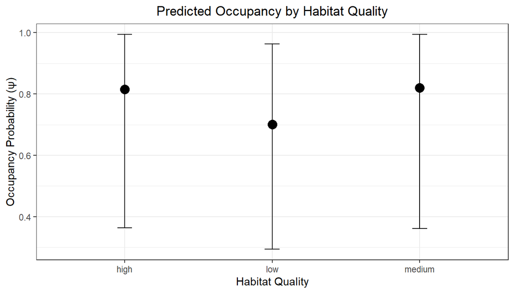

## Comparison Table

```
##      comparison probability
## 1 High > Medium   0.5006667
## 2    High > Low   0.7593333
## 3  Medium > Low   0.7730000
```

From the pairwise comparisons, there is moderate support for higher occupancy in medium and high quality habitats relative to low quality habitat. In contrast there is little to no support for a difference between high and medium quality habitats.

## Comparison Plot

The following plot visualizes predicted habitat class preference probabilities.

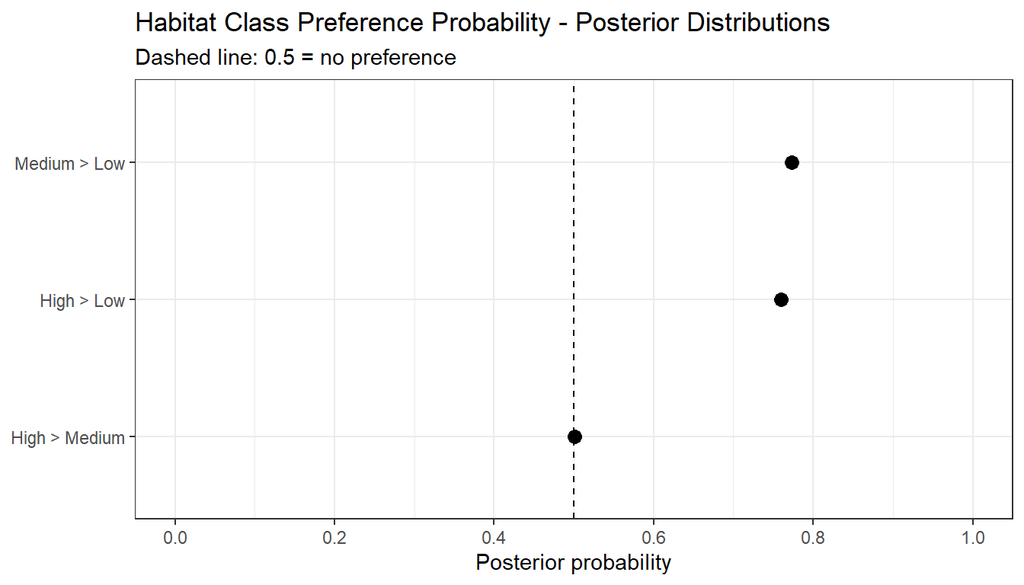

# Summary Statement

This analysis applied a hierarchical occupancy modeling framework to quantify both site occupancy and detection processes for Gila monsters in southern Utah while accounting for imperfect detection.

Model selection, bootstrap inference, and variable-importance analyses identified wind speed, substrate conditions, and air temperature as the primary effetcs on detection probability, and these covariates were incorporated into a Bayesian occupancy model. Occupancy estimates indicated high site use across the study area, with predicted occupancy probabilities exceeding 80% under mean-centered conditions. Habitat-class comparisons suggested modest increases in occupancy in medium and high quality habitats relative to low quality habitats, though differences exhibit significant uncertainty. Detection probability during a survey was low (~2.7%), highlighting the importance of repeated sampling and optimal survey conditions when searching for Gila monsters. These results aim to provide a framework for understanding spatial patterns of Gila monster site occupancy and survey detectability to inform future monitoring and habitat management.